# Early Gestation RNAseq

Justin Bogias

01 Aug, 2024

# Load Packages

```r
library(tidyverse)
library(magrittr)
library(edgeR)
library(DRIMSeq)
library(DESeq2)
library(stageR)
library(ggplot2)
library(cowplot)
library(AnnotationHub)
library(ensembldb)
library(ggfortify)
library(ggrepel)
library(DT)
library(quantro)
library(qsmooth)
library(VennDiagram)
library(goseq)
library(here)
```

# Annotations

For the annotations I elected to use the more recent annotations for gene and transcript length. Recent length annotations are more reliable than previous versions and they have been used in this analysis.

```r
ah <- AnnotationHub()

ensDb <- ah[["AH78783"]]
```

```
## loading from cache
```

```r
genesGR <- ensembldb::genes(ensDb)
transGR <- transcripts(ensDb)
transGR$gene_name <- mcols(genesGR)[mcols(transGR)$gene_id,"gene_name"]
transGR$length <- lengthOf(ensDb, "tx")

tibble(x = 1:10, y = 2:11) %>% set_colnames(c("a", "b"))
```

```
## # A tibble: 10 × 2
##        a     b
##    <int> <int>
##  1     1     2
##  2     2     3
##  3     3     4
##  4     4     5
##  5     5     6
##  6     6     7
##  7     7     8
##  8     8     9
##  9     9    10
## 10    10    11
```

```r
ensDb <- ah[["AH10684"]]
```

```
## loading from cache
```

```r
transcript_names <- ensDb %>%
  as.data.frame() %>%
  dplyr::filter(type == "transcript") %>%
  dplyr::select("transcript_id",
                "transcript_name")

grch38_txp_anno <- transGR %>%
  as.data.frame() %>%
  dplyr::select("gene_id",
                "gene_name",
                "transcript_id" = "tx_id",
                "width",
                "length",
                "chromosome" = "seqnames",
                "transcript_biotype" = "tx_biotype") %>%
  left_join(transcript_names,
            by = "transcript_id") %>%
  as_tibble()

grch38_gene_anno <- genesGR %>%
  as.data.frame() %>%
  dplyr::select("gene_id",
                "gene_name",
                "length" = "width",
                "chromosome" = "seqnames",
                "gene_biotype") %>%
  as_tibble()
```

# Data import

Now it’s time to import the RNA-seq data. However, samples that were not pure chorionic villus tissue need to be removed from further analyses. Two other samples also had extremely poor sequencing quality and will also be removed. The samples are removed to mitigate any technical or systematic bias in the results.

```r
impure_samples <- c(
  "PAC006", "PAC008", "PAC024", "PAC025",
  "PAC034", "PAC035", "PAC039", "PAC041",
  "PAC036", "PAC045", "PAC071", "PAC131"
  )
```

Load in the patient metadata. The `Trimester` and `Timepoint` fields have been mutated into the metadata. `Trimester` defines whether the gestational age falls within the first (0 - 12 weeks) or second (13 - 26 weeks) trimesters of pregnancy.

```r
pd <- here("data/metadata/metadata.csv") %>%
  read_csv() %>%
  dplyr::filter(Cohort == "PAC") %>%
  mutate(
    Trimester = as.factor(Trimester),
    Timepoint = ifelse(GestationalAge <= 10, "6-10weeks", "11-23weeks"),
    Timepoint = factor(Timepoint, levels = c("6-10weeks", "11-23weeks"))
  )
```

Load in the transcript counts returned from quantification with *salmon* after implementation of the Selective Alignment method. The counts were imported into R through the use of the `catchSalmon` function in `edgeR` prior to this analysis.

```r
transCounts <- readRDS(here("data/counts/salmon_object.rds"))

rownames(transCounts$counts) <-  gsub(
  "\\..*",
  "",
  rownames(transCounts$counts)
)

rownames(transCounts$annotation) <-  gsub(
  "\\..*",
  "",
  rownames(transCounts$annotation)
)

colnames(transCounts$counts) <- colnames(transCounts$counts) %>%
  basename() %>%
  enframe(name = NULL) %>%
  inner_join(pd,
             by = c("value" = "filenames")) %>%
  .[["ID"]]
```

Import transcript abundances calculated from *salmon*. These counts are validated TPMs calculated from salmon. They differ slightly from TPMs calculated directly from the counts in that there are certain validation steps which were used to generate them. They are useful for visualisation of transcripts in TPM

```r
abundance_salmon <- read_csv(here("data/counts/grch37_PAC_abundance.csv.gz"))
abundance_salmon <- abundance_salmon %>%
  mutate(transcript_id = str_remove(transcript_id, "\\..*")) %>%
  column_to_rownames("transcript_id")

colnames(abundance_salmon) <- colnames(abundance_salmon) %>%
  basename() %>%
  enframe(name = NULL) %>%
  inner_join(pd,
             by = c("value" = "filenames")) %>%
  .[["ID"]]

abundance_salmon <- abundance_salmon %>%
  rownames_to_column("transcript_id") %>%
  as_tibble()
```

# Data Preparation

```r
autosomeTxpID <- grch38_txp_anno %>%
  dplyr::filter(
    !chromosome %in% c("MT", "X", "Y")
    ) %>%
  as.matrix() %>%
  as.character() %>%
  intersect(
    rownames(transCounts$counts)
    )

transCounts$counts <- transCounts$counts[autosomeTxpID,]
transCounts$annotation <- transCounts$annotation[autosomeTxpID,]

abundance_salmon <- abundance_salmon %>%
  dplyr::filter(
    transcript_id %in% autosomeTxpID
  )
```

# Create DGElist

```r
# aggregate the counts using simply aggregation -------------
txp_mat <- transCounts$counts

#gene_counts <- txp_mat %>%

gene_counts <- txp_mat %>%
  as.data.frame() %>%
  rownames_to_column(
    var = "transcript_id"
  ) %>%
  left_join(
    grch38_txp_anno,
    by = "transcript_id"
  ) %>%
  dplyr::select(
    -"transcript_id"
  ) %>%
  group_by(gene_id) %>%
  summarise_if(
    is.numeric,
    sum
  ) %>%
  dplyr::select(
    -length,
    -width
  ) %>%
  dplyr::filter(
    !is.na(gene_id)
  ) %>%
  as.data.frame() %>%
  column_to_rownames("gene_id") %>%
  as.matrix() %>%
  round(0)
```

```r
filterCounts <- function (
  x,
  minCPM = 2,
  minSamp = 27
) {
  cpm <- cpm(x)
  i <- rowSums(cpm > minCPM) > minSamp
  x[i,]
}
```

Now remove alternate chromosome builds

```r
dge_counts <- gene_counts %>%
  as.data.frame() %>%
  rownames_to_column("gene_id") %>%
  dplyr::filter(str_detect(gene_id, "^E")) %>%
  as.data.frame() %>%
  column_to_rownames("gene_id") %>%
  as.matrix() %>%
  filterCounts() %>%
  .[,!colnames(.) %in% impure_samples]
```

Create DGElist

```r
DGElist <- dge_counts %>%
  DGEList(
    samples = colnames(.) %>%
      enframe(name = NULL, value = "ID") %>%
      left_join(pd),
    genes = rownames(.) %>%
      enframe(name = NULL, value = "gene_id") %>%
      left_join(grch38_gene_anno,
                by = "gene_id"))
```

# Smooth quantile normalisation

The *quantro* package can be used to test for global differences in distributions between groups to guide the choice of whether it is appropriate to use global normalization methods, such as quantile normalisation. For instance, if the variability between groups is larger than the variability within each group then there may be global differences present rendering quantile normalisation inappropriate (depending on the type and source of variation)

As described in the quantro paper the main function performs two tests. * An ANOVA to test if the medians of distributions are different across groups. Differences across groups could be attributed to unwanted technical variation (such as batch effects) or real global biological variation. This is a helpful step for the user to verify if there is any technical variation unaccounted for.

- A test for global differences between the distributions across groups which returns a test statistic called quantroStat. This test statistic is a ratio of two variances (similar to the idea of ANOVA): the variability of the distributions within groups relative to the variability between groups. If the variability between groups is sufficiently larger than the variability within groups, then this suggests global adjustment methods may not be appropriate.

The reader is encouraged to look to the original paper for more information if desired.

```r
eset <- ExpressionSet(
  assayData = round(DGElist$counts, 0),
  phenoData = AnnotatedDataFrame(
    pd %>%
      as.data.frame() %>%
      set_rownames(.$ID) %>%
      .[colnames(DGElist$counts),]
    )
  )

keepMeID <- sapply(
  1:nrow(eset),
  function (x) { any(exprs(eset)[x,] != 0) }
)
eset <- eset[keepMeID,]

ds <- DESeqDataSetFromMatrix(
  countData = eset,
  colData = pData(eset),
  design = ~ Timepoint
)
```

```
##   Note: levels of factors in the design contain characters other than
##   letters, numbers, '_' and '.'. It is recommended (but not required) to use
##   only letters, numbers, and delimiters '_' or '.', as these are safe characters
##   for column names in R. [This is a message, not a warning or an error]
```

```r
r_ds <- vst(ds)
r_ds_mat <- as.matrix(assay(r_ds))

matdensity(
  r_ds_mat,
  groupFactor = pData(eset)$Timepoint,
  xlab = "counts",
  ylab = "density",
  main = "Gene counts",
  brewer.n = 8,
  brewer.name = "Dark2"
  )
legend(
  'top',
  c("NeuN_neg", "NeuN_pos"),
  col = c(1, 2),
  lty = 1,
  lwd = 3
)
```

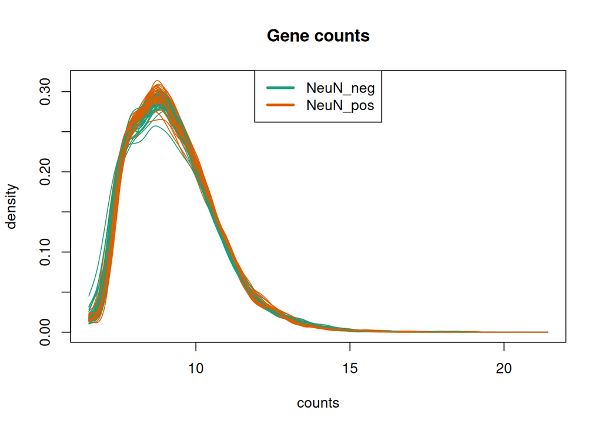

The results of the quantro test

```r
qFit <- quantro(
  r_ds_mat,
  groupFactor = pData(eset)$Timepoint,
  B = 1000
)
```

```
## [quantro] Average medians of the distributions are
##                         not equal across groups.
```

```
## [quantro] Calculating the quantro test statistic.
```

```
## [quantro] Starting permutation testing.
```

```
## [quantro] Using a single core (backend: doSEQ,
##                         version: 1.5.2).
```

```r
print(qFit)
```

```
## quantro: Test for global differences in distributions
##    nGroups:  2
##    nTotSamples:  84
##    nSamplesinGroups:  27 57
##    anovaPval:  0
##    quantroStat:  15.25473
##    quantroPvalPerm:  < 0.001
```

```r
qs <- qsmooth(
  exprs(eset),
  group_factor = pData(eset)$Timepoint
)

DGElist$counts <- qs@qsmoothData

DGElist %>%
  write_rds(here("data/counts/dgelist.rds"))
```

Transcripts were considered as detectbale if above 2CPM in more than 27 samples.

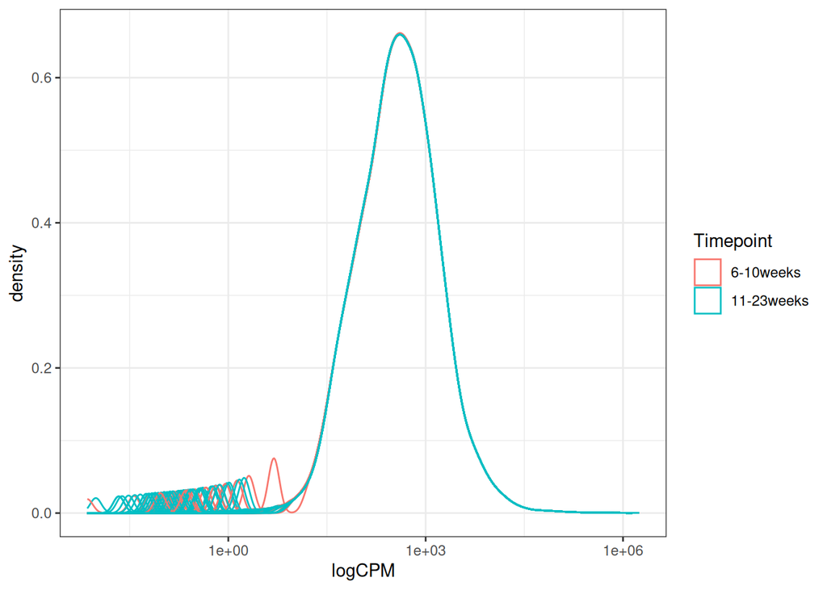

```r
qsmooth::qsmoothData(qs) %>%
  as.data.frame() %>%
  rownames_to_column("gene") %>%
  pivot_longer(
    cols = starts_with("PAC"),
    names_to = "ID",
    values_to = "logCPM"
  ) %>%
  left_join(pd) %>%
  ggplot(
    aes(
      logCPM,
      stat(density),
      colour = Timepoint,
      group = ID
      )
  ) +
  geom_density() +
  scale_x_log10() +
  theme_bw()
```

# Principal Component Analysis

## Figure 1 - PCA

The samples are spread on the first principle component by gestational age

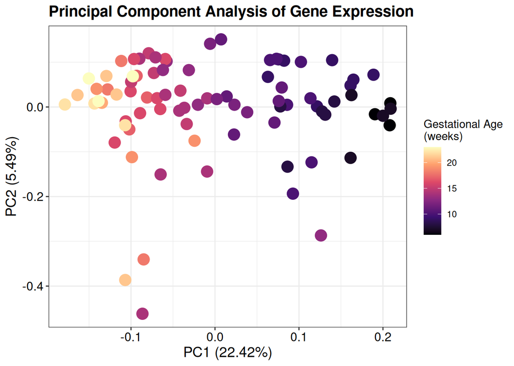

```r
DGElist$counts %>%
  cpm(log = TRUE) %>%
  t() %>%
  prcomp() %>%
  autoplot(
    data = DGElist$samples,
    colour = "GestationalAge",
    size = 5
  ) +
  ggtitle("Principal Component Analysis of Gene Expression") +
  labs(colour = "Gestational Age\n(weeks)") +
  scale_colour_viridis_c(option = "magma") +
  theme_bw() +
  theme(axis.title = element_text(size = 14,
                                  colour = "black"),
        axis.text = element_text(size = 12,
                                 colour = "black"),
        plot.title = element_text(size = 15,
                                  colour = "black",
                                  face = "bold")
  )
```

# Differential Expression Analysis

```r
alpha <- 0.05
lambda <- 1.4
```

For differential transcript expression we are testing to see if the expression of individual transcripts are exceeding a logFC between the before and after 10 weeks’ samples as specified by $\lambda$ using the `glmQLFit` function.

null: logFC is betweem -$\lambda$ and +$\lambda$ alternate: absolute value of logFC is greater than $\lambda$

For all analyses for the value $\lambda$ the value 1.4 was chosen

```r
designMatrix <- model.matrix(
  ~ Timepoint +
    FetalSex,
  data = DGElist$samples
)

colnames(designMatrix) <- colnames(designMatrix) %>%
  str_remove("Timepoint") %>%
  str_remove("FetalSex")

DGElist <- DGElist %>%
  estimateCommonDisp(
    design = designMatrix
  )

oxygenGenes <- glmQLFit(DGElist,
                        design = designMatrix) %>%
  glmTreat(coef = "11-23weeks",
           lfc = log2(lambda)) %>%
  topTags(n = Inf) %>%
  .[["table"]] %>%
  as_tibble() %>%
  dplyr::mutate(DE = FDR < alpha & abs(logFC) > 1) %>%
  dplyr::rename("Gene" = "gene_id",
                "GeneName" = "gene_name",
                "Gene_biotype" = "gene_biotype")

sig_genes <- oxygenGenes %>%
  dplyr::filter(FDR < 0.05 & abs(logFC) > 1)
```

Run a dimension on this for reproducibility

```r
print(dim(sig_genes))
```

```
## [1] 884  11
```

Save results

```r
oxygenGenes %>%
  write_csv(here("data/results/oxygenGenes.csv.gz"))

sig_genes %>%
  write_csv(here("data/results/sig_genes.csv.gz"))
```

# Create DTElist

Create DTElist and calculate normalisation factors using qsmooth. A common, but uncommonly addressed, question which arises in RNA-seq analyses is if the normalisation methods used in the workflow are appropriate based on the distribution of the reads in the data. There is a risk of normalising the biological differences in the data in certain scenarios which may be unnecessary, and at worst inappropriate, for the data under analysis. Most differential expression methods operate under the assumption that only a small proportion of the genes in question are differentially expressed and that differences in read distributions between testing samples are due to technical issues in the data.

```r
filterCounts <- function (
  x,
  minCPM = 2,
  minSamp = 27
) {
  cpm <- cpm(x)
  i <- rowSums(cpm > minCPM) > minSamp
  x[i,]
}
```

Now remove alternate chromosome builds

```r
dte_counts <- transCounts %>%
 with(counts / annotation$Overdispersion) %>%
  as.data.frame() %>%
  rownames_to_column("transcript_id") %>%
  dplyr::filter(str_detect(transcript_id, "^E")) %>%
  as.data.frame() %>%
  column_to_rownames("transcript_id") %>%
  as.matrix() %>%
  filterCounts() %>%
  .[,!colnames(.) %in% impure_samples]
```

Create DTElist

```r
DTElist <- dte_counts %>%
  DGEList(
    samples = colnames(.) %>%
      enframe(name = NULL, value = "ID") %>%
      left_join(pd),
    genes = rownames(.) %>%
      enframe(name = NULL, value = "transcript_id") %>%
      left_join(grch38_txp_anno,
                by = "transcript_id"))
```

# Smooth quantile normalisation

The *quantro* package can be used to test for global differences in distributions between groups to guide the choice of whether it is appropriate to use global normalization methods, such as quantile normalisation. For instance, if the variability between groups is larger than the variability within each group then there may be global differences present rendering quantile normalisation inappropriate (depending on the type and source of variation)

As described in the quantro paper the main function performs two tests. * An ANOVA to test if the medians of distributions are different across groups. Differences across groups could be attributed to unwanted technical variation (such as batch effects) or real global biological variation. This is a helpful step for the user to verify if there is any technical variation unaccounted for.

- A test for global differences between the distributions across groups which returns a test statistic called quantroStat. This test statistic is a ratio of two variances (similar to the idea of ANOVA): the variability of the distributions within groups relative to the variability between groups. If the variability between groups is sufficiently larger than the variability within groups, then this suggests global adjustment methods may not be appropriate.

The reader is encouraged to look to the original paper for more information if desired.

```r
eset <- ExpressionSet(
  assayData = round(DTElist$counts, 0),
  phenoData = AnnotatedDataFrame(
    pd %>%
      as.data.frame() %>%
      set_rownames(.$ID) %>%
      .[colnames(DTElist$counts),]
    )
  )

keepMeID <- sapply(
  1:nrow(eset),
  function (x) { any(exprs(eset)[x,] != 0) }
)
eset <- eset[keepMeID,]

ds <- DESeqDataSetFromMatrix(
  countData = eset,
  colData = pData(eset),
  design = ~ Timepoint
)
```

```
##   Note: levels of factors in the design contain characters other than
##   letters, numbers, '_' and '.'. It is recommended (but not required) to use
##   only letters, numbers, and delimiters '_' or '.', as these are safe characters
##   for column names in R. [This is a message, not a warning or an error]
```

```r
r_ds <- vst(ds)
r_ds_mat <- as.matrix(assay(r_ds))

matdensity(
  r_ds_mat,
  groupFactor = pData(eset)$Timepoint,
  xlab = "counts",
  ylab = "density",
  main = "Transcript counts",
  brewer.n = 8,
  brewer.name = "Dark2"
  )
legend(
  'top',
  c("NeuN_neg", "NeuN_pos"),
  col = c(1, 2),
  lty = 1,
  lwd = 3
)
```

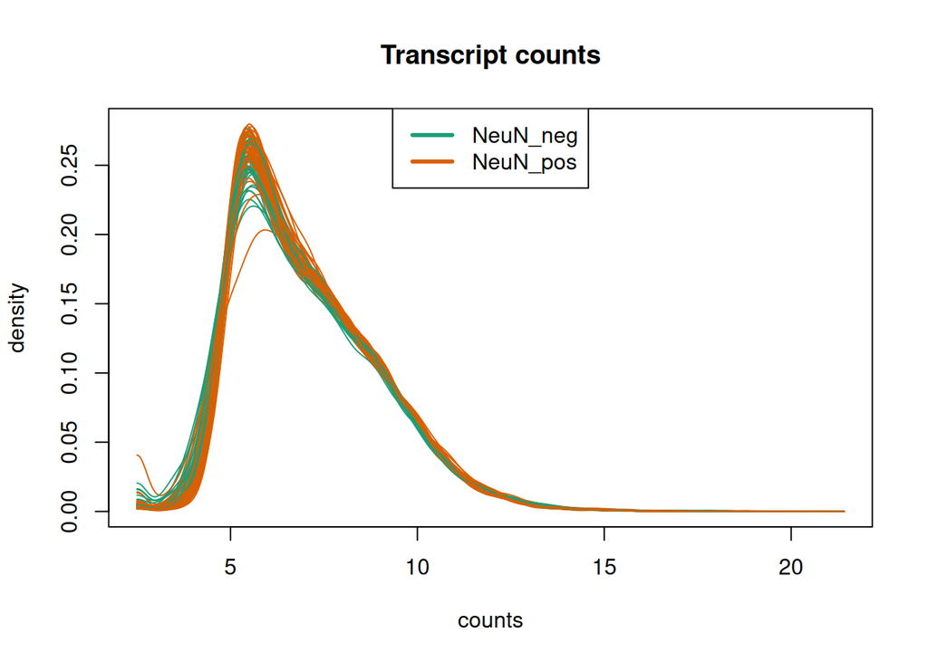

The results of the quantro test

```r
qFit <- quantro(
  r_ds_mat,
  groupFactor = pData(eset)$Timepoint,
  B = 1000
)
```

```
## [quantro] Average medians of the distributions are
##                         not equal across groups.
```

```
## [quantro] Calculating the quantro test statistic.
```

```
## [quantro] Starting permutation testing.
```

```
## [quantro] Using a single core (backend: doSEQ,
##                         version: 1.5.2).
```

```r
print(qFit)
```

```
## quantro: Test for global differences in distributions
##    nGroups:  2
##    nTotSamples:  84
##    nSamplesinGroups:  27 57
##    anovaPval:  0
##    quantroStat:  6.67969
##    quantroPvalPerm:  0.002
```

```r
qs <- qsmooth(
  exprs(eset),
  group_factor = pData(eset)$Timepoint
)

DTElist$counts <- qs@qsmoothData

DTElist %>%
  write_rds(here("data/counts/dtelist.rds"))
```

Transcripts were considered as detectbale if above 2CPM in more than 27 samples.

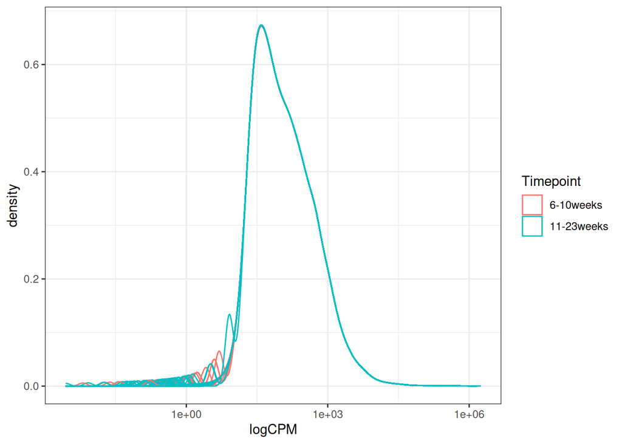

```r
qsmooth::qsmoothData(qs) %>%
  as.data.frame() %>%
  rownames_to_column("gene") %>%
  pivot_longer(
    cols = starts_with("PAC"),
    names_to = "ID",
    values_to = "logCPM"
  ) %>%
  left_join(pd) %>%
  ggplot(
    aes(
      logCPM,
      stat(density),
      colour = Timepoint,
      group = ID
      )
  ) +
  geom_density() +
  scale_x_log10() +
  theme_bw()
```

# Principal Component Analysis

## Figure 1 - PCA

```r
fig1 <- DTElist$counts %>%
  cpm(log = TRUE) %>%
  t() %>%
  prcomp() %>%
  autoplot(
    data = DTElist$samples,
    colour = "GestationalAge",
    size = 5
  ) +
  scale_colour_viridis_c(option = "magma") +
  ggtitle("Principal Component Analysis of Transcript Expression") +
  labs(colour = "Gestational Age\n(weeks)") +
  theme_bw() +
  theme(axis.title = element_text(size = 20,
                                  colour = "black"),
        legend.title = element_text(size = 20,
                                    colour = "black"),
        legend.text = element_text(size = 18,
                                   colour = "black"),
        axis.text = element_text(size = 18,
                                 colour = "black"),
        plot.title = element_text(size = 20,
                                  colour = "black",
                                  face = "bold")
  )

ggsave(filename = "Figure_1.png",
       plot = fig1,
       device = "png",
       path = here("data/figures"),
       height = 21.725,
       width = 27.5,
       units = "cm",
       dpi = 300)
```

# Differential Expression Analysis

```r
alpha <- 0.05
lambda <- 1.4
```

For differential transcript expression we are testing to see if the expression of individual transcripts are exceeding a logFC between the before and after 10 weeks’ samples as specified by $\lambda$ using the `glmQLFit` function.

null: logFC is betweem -$\lambda$ and +$\lambda$ alternate: absolute value of logFC is greater than $\lambda$

For all analyses for the value $\lambda$ the value 1.4 was chosen

```r
designMatrix <- model.matrix(
  ~ Timepoint +
    FetalSex,
  data = DTElist$samples
)

colnames(designMatrix) <- colnames(designMatrix) %>%
  str_remove("Timepoint") %>%
  str_remove("FetalSex")


DTElist <- DTElist %>%
  estimateCommonDisp(
    design = designMatrix
  )

oxygenTranscripts <- glmQLFit(DTElist,
                              design = designMatrix) %>%
  glmTreat(coef = "11-23weeks",
           lfc = log2(lambda)) %>%
  topTags(n = Inf) %>%
  .[["table"]] %>%
  as_tibble() %>%
  dplyr::mutate(DE = FDR < alpha & abs(logFC) > 1) %>%
  dplyr::rename("Transcript" = "transcript_id",
                "TranscriptName" = "transcript_name",
                "Transcript_biotype" = "transcript_biotype",
                "Gene" = "gene_id",
                "GeneName" = "gene_name")

sig_tx <- oxygenTranscripts %>%
  dplyr::filter(FDR < 0.05 & abs(logFC) > 1)
```

Check dimensions here

```r
print(dim(sig_tx))
```

```
## [1] 1017   14
```

Save results

```r
oxygenTranscripts %>%
  write_csv(here("data/results/oxygenTranscripts.csv.gz"))

sig_tx %>%
  write_csv(here("data/results/sig_tx.csv.gz"))
```